# R Crashcourse

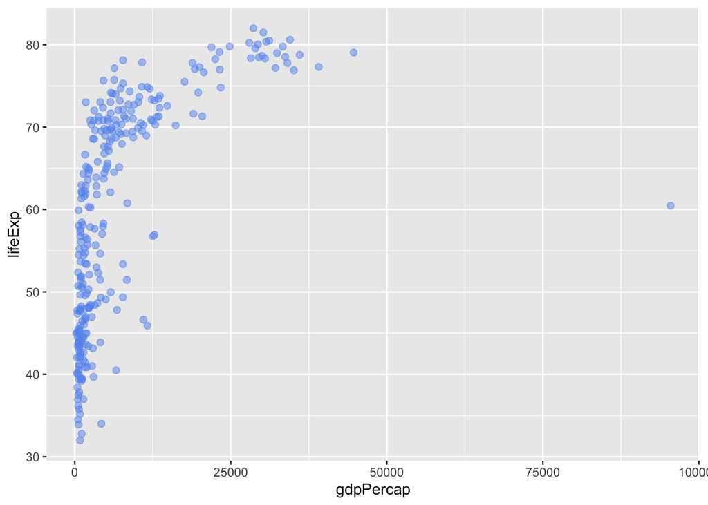

```r
## adding stuff like colors, transparency and marker size
ggplot(data=plot_data,
       mapping=aes(x=gdpPercap,
                   y=lifeExp)) +
  geom_point(color = "cornflowerblue",
             alpha = 0.5,
             size = 2)
```

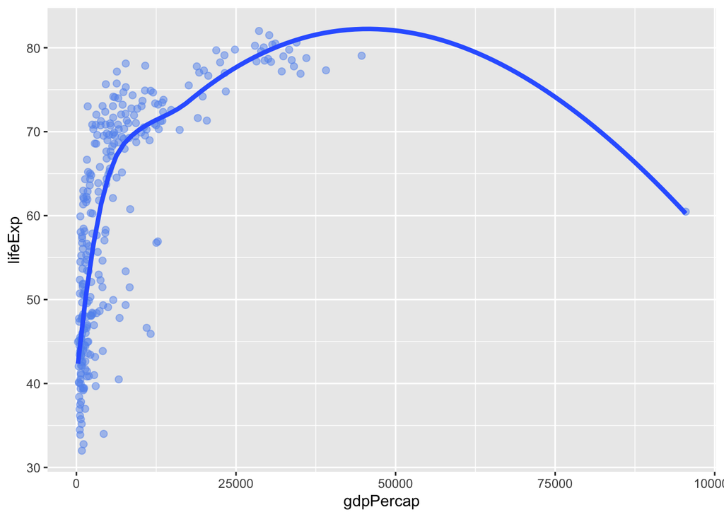

```r
## add a best-fit line
ggplot(data=plot_data,
       mapping=aes(x=gdpPercap,
                   y=lifeExp)) +
  geom_point(color = "cornflowerblue",
             alpha = 0.5,
             size = 2) +
  geom_smooth(method = "loess",
              se=FALSE,
              linewidth=1.5)
```

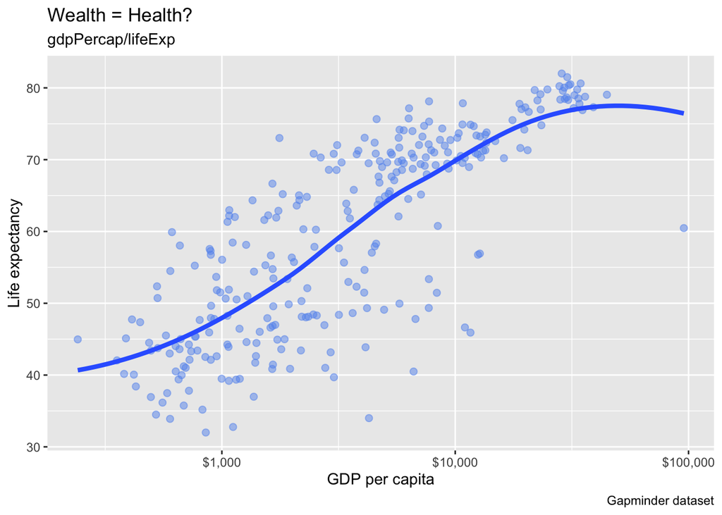

```r
## Add labels and captions, and logging the x-axis
ggplot(data=plot_data,
       mapping=aes(x=gdpPercap,
                   y=lifeExp)) +
  geom_point(color = "cornflowerblue",
             alpha = 0.5,
             size = 2) +
  geom_smooth(method = "loess",
              se=FALSE,
              linewidth=1.5) +
  scale_x_log10(breaks = c(100, 1000, 10000, 100000),
                     label = scales::dollar) +
  labs(x = "GDP per capita",
       y = "Life expectancy",
       title = "Wealth = Health?",
       subtitle = "gdpPercap/lifeExp",
       caption = "Gapminder dataset",
       color = "Year")
```

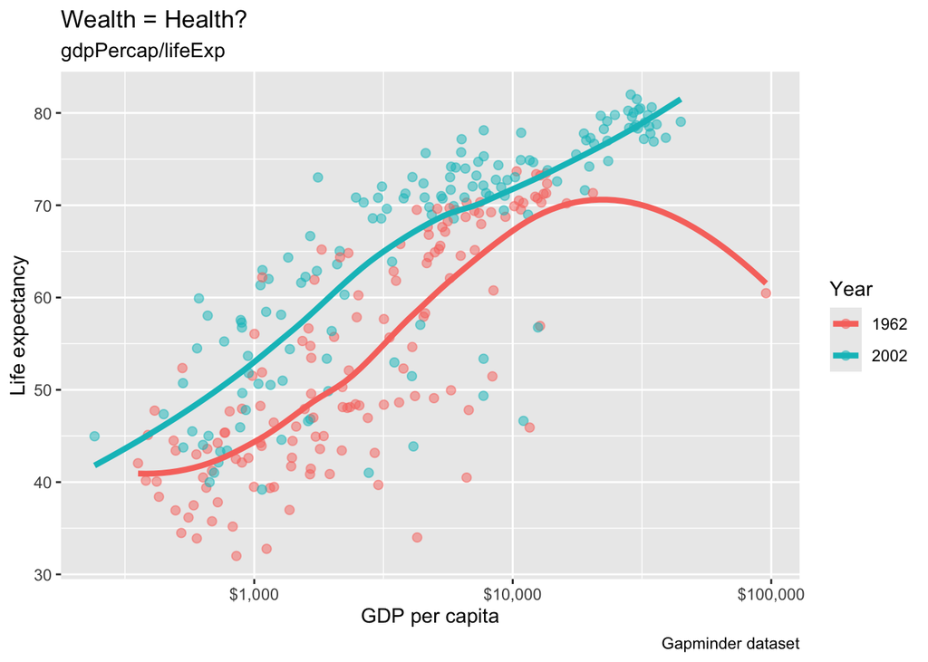

```r
## grouping using colors
ggplot(data=plot_data,
       mapping=aes(x=gdpPercap,
                   y=lifeExp,
                   color=as.factor(year))) +
  geom_point(alpha = 0.5,
             size = 2) +
  geom_smooth(method = "loess",
              se=FALSE,
              linewidth=1.5) +
  scale_x_log10(breaks = c(100, 1000, 10000, 100000),
                     label = scales::dollar) +
  labs(x = "GDP per capita",
       y = "Life expectancy",
       title = "Wealth = Health?",
       subtitle = "gdpPercap/lifeExp",
       caption = "Gapminder dataset",
       color = "Year")
```

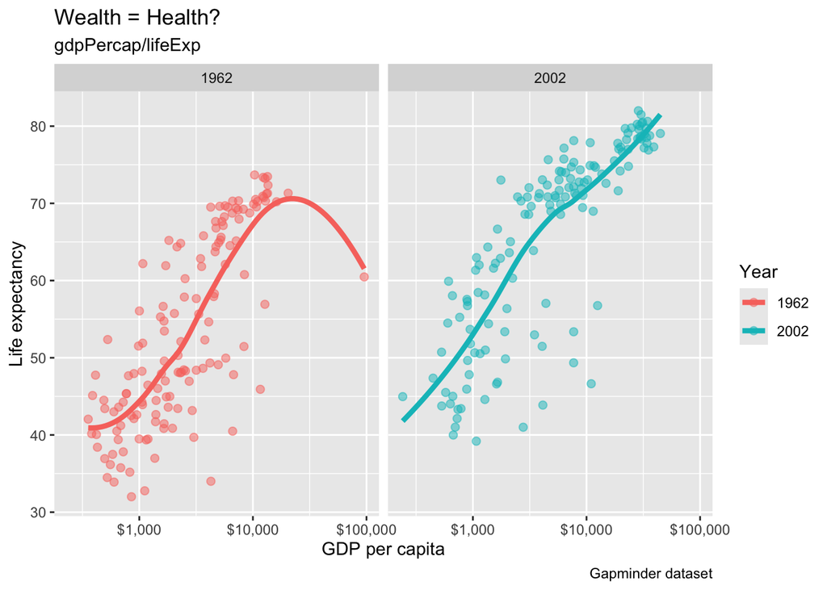

```r
## grouping using facets
ggplot(data=plot_data,
       mapping=aes(x=gdpPercap,
                   y=lifeExp,
                   color=as.factor(year))) +
  geom_point(alpha = 0.5,
             size = 2) +
  geom_smooth(method = "loess",
              se=FALSE,
              linewidth=1.5) +
  scale_x_log10(breaks = c(100, 1000, 10000, 100000),
                     label = scales::dollar) +
  labs(x = "GDP per capita",
       y = "Life expectancy",
       title = "Wealth = Health?",
       subtitle = "gdpPercap/lifeExp",
       caption = "Gapminder dataset",
       color = "Year") +
  facet_wrap(~as.factor(year))
```

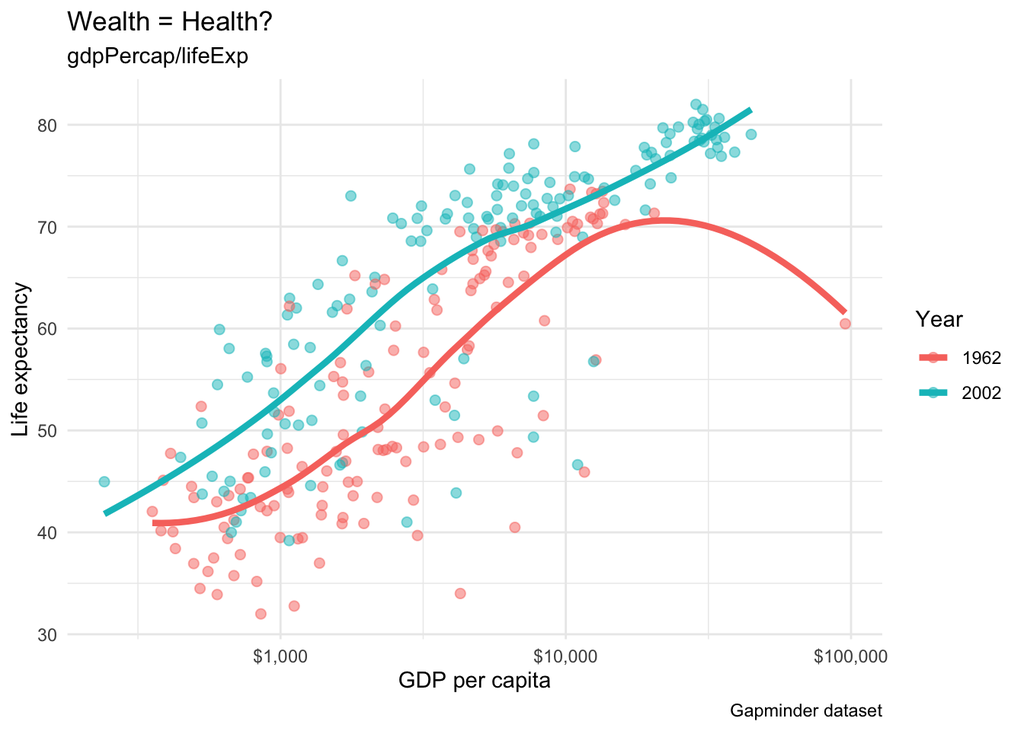

```r
## Adding a theme
ggplot(data=plot_data,
       mapping=aes(x=gdpPercap,
                   y=lifeExp,
                   color=as.factor(year))) +
  geom_point(alpha = 0.5,
             size = 2) +
  geom_smooth(method = "loess",
              se=FALSE,
              linewidth=1.5) +
  scale_x_log10(breaks = c(100, 1000, 10000, 100000),
                     label = scales::dollar) +
  labs(x = "GDP per capita",
       y = "Life expectancy",
       title = "Wealth = Health?",
       subtitle = "gdpPercap/lifeExp",
       caption = "Gapminder dataset",
       color = "Year") +
  theme_minimal()
```

You can control the size and alignment of your graphs in R Markdown by specifying options directly in the code chunk. You can also add a figure caption.

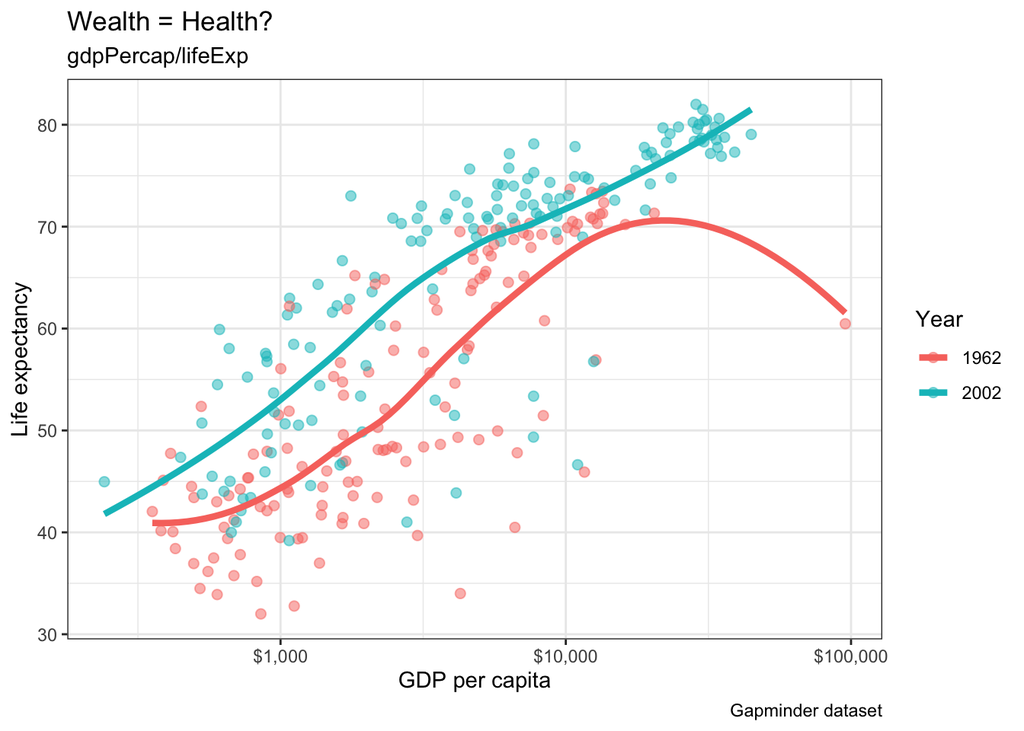

A nice-looking image!

In case you want to play around with colors, here’s a [cheatsheet](http://www.stat.columbia.edu/~tzheng/files/Rcolor.pdf).

## Pivoting Data

**Question:** what format is `plot_data` in?

For practice, let’s pivot `plot_data`:

```r
# from long to wide
dta_pivot <- plot_data |>
  select(year, lifeExp, country) |>
  pivot_wider(names_from=year,
              values_from = lifeExp,
              names_prefix = "Year")



# pivoting back
dta_pivot <- dta_pivot |>
  pivot_longer(
    cols = starts_with("Year"),
    names_to = "year",
    names_prefix = "Year",
    values_to = "lifeExp"
  )
```

## Joining Datasets (In-Class Exercise)

Finally, you may want to `join` (or “merge” in Stata-talk) different datasets.

Have a look at the different join options [here](https://r4ds.hadley.nz/joins.html#how-do-joins-work).

Try yourself to join the `polity4` data to `dta`.

Hint: you will need to `pivot` one of the two datasets.

```r
# in class exercise
```

You may have noticed that your join didn’t work perfectly because of some inconsistencies in how country names are spelled in the two different datasets.

To get around this issue, researchers have come up with unique country codes.

One commonly used set of codes comes from the **Correlates of War (COW)** project.

There’s even a package for it. See [here](https://rforpoliticalscience.com/2020/06/03/add-correlates-of-war-codes-in-r-with-countrycode-package/)